# Week 9

Shrey Kothari

2025-12-03

Step 1:

Model From Last Week:

```r
library(tidyverse)
data <- read_csv("cox-violent-parsed.csv")
```

```
## ──────────────────────────────────────────────────────── Delimiter: "," chr
## (33): name, first, last, compas_screening_date, sex, dob, age_cat, race,... dbl
## (18): id, age, juv_fel_count, decile_score...12, juv_misd_count, juv_oth... lgl
## (1): violent_recid
```

```r
set.seed(862331611)
rows <- nrow(data)
trainIndex <- sample(1:rows, size = 0.7*rows)
trainData <- data[trainIndex, ]
testData <- data[-trainIndex, ]
trainData <- trainData %>%
  rename(priors_count = priors_count...15)
testData <- testData %>%
  rename(priors_count = priors_count...15)
trainData <- trainData %>%
  rename(decile_score = decile_score...12)
testData <- testData %>%
  rename(decile_score = decile_score...12)

variablesOfInterest <- c("is_recid", "race", "age", "priors_count", "juv_fel_count", "decile_score")
df <- trainData[, variablesOfInterest]
```

```r
model <- lm(is_recid ~ race + age + I(age^2) +
            juv_fel_count + I(juv_fel_count^2) + priors_count + I(priors_count^2) +
            decile_score + age*juv_fel_count + race*priors_count, data = df)
summary(model)
```

```
##
## Call:
## lm(formula = is_recid ~ race + age + I(age^2) + juv_fel_count +
##     I(juv_fel_count^2) + priors_count + I(priors_count^2) + decile_score +
##     age * juv_fel_count + race * priors_count, data = df)
##
## Residuals:
##      Min       1Q   Median       3Q      Max
## -1.49731 -0.37813 -0.05311  0.46756  1.08648
##
## Coefficients:
##                                    Estimate Std. Error t value Pr(>|t|)
## (Intercept)                       0.8495228  0.0514996  16.496  < 2e-16 ***
## raceAsian                        -0.3278871  0.0914447  -3.586 0.000338 ***
## raceCaucasian                    -0.0064460  0.0132959  -0.485 0.627816
## raceHispanic                     -0.0886265  0.0218408  -4.058 4.98e-05 ***
## raceNative American              -0.1401922  0.1045561  -1.341 0.179999
## raceOther                        -0.0155050  0.0264454  -0.586 0.557682
## age                              -0.0294602  0.0025873 -11.386  < 2e-16 ***
## I(age^2)                          0.0002614  0.0000312   8.379  < 2e-16 ***
## juv_fel_count                     0.0897629  0.0435536   2.061 0.039326 *
## I(juv_fel_count^2)               -0.0023367  0.0016545  -1.412 0.157871
## priors_count                      0.0661378  0.0024968  26.489  < 2e-16 ***
## I(priors_count^2)                -0.0018140  0.0001018 -17.821  < 2e-16 ***
## decile_score                      0.0103750  0.0021268   4.878 1.08e-06 ***
## age:juv_fel_count                -0.0028408  0.0013110  -2.167 0.030256 *
## raceAsian:priors_count            0.1397159  0.0429240   3.255 0.001137 **
## raceCaucasian:priors_count        0.0060843  0.0021933   2.774 0.005544 **
## raceHispanic:priors_count         0.0101357  0.0050068   2.024 0.042951 *
## raceNative American:priors_count  0.0236741  0.0108301   2.186 0.028836 *
## raceOther:priors_count            0.0177772  0.0053846   3.302 0.000964 ***
## ---
## Signif. codes:  0 '***' 0.001 '**' 0.01 '*' 0.05 '.' 0.1 ' ' 1
##
## Residual standard error: 0.5273 on 12802 degrees of freedom
## Multiple R-squared:  0.1598, Adjusted R-squared:  0.1587
## F-statistic: 135.3 on 18 and 12802 DF,  p-value: < 2.2e-16
```

Partial F-Tests:

```r
reduced_age <- lm(is_recid ~ race + age +
                   juv_fel_count + I(juv_fel_count^2) +
                   priors_count + I(priors_count^2) +
                   decile_score +
                   age*juv_fel_count + race*priors_count,
                   data = df)
anova(reduced_age, model)
```

```
## Analysis of Variance Table
##
## Model 1: is_recid ~ race + age + juv_fel_count + I(juv_fel_count^2) +
##     priors_count + I(priors_count^2) + decile_score + age * juv_fel_count +
##     race * priors_count
## Model 2: is_recid ~ race + age + I(age^2) + juv_fel_count + I(juv_fel_count^2) +
##     priors_count + I(priors_count^2) + decile_score + age * juv_fel_count +
##     race * priors_count
##   Res.Df    RSS Df Sum of Sq    F    Pr(>F)
## 1  12803 3579.6
## 2  12802 3560.0  1    19.521 70.2 < 2.2e-16 ***
## ---
## Signif. codes:  0 '***' 0.001 '**' 0.01 '*' 0.05 '.' 0.1 ' ' 1
```

```r
reduced_juv <- lm(is_recid ~ race + age + I(age^2) +
                   juv_fel_count +
                   priors_count + I(priors_count^2) +
                   decile_score +
                   age*juv_fel_count + race*priors_count,
                   data = df)
anova(reduced_juv, model)
```

```
## Analysis of Variance Table
##
## Model 1: is_recid ~ race + age + I(age^2) + juv_fel_count + priors_count +
##     I(priors_count^2) + decile_score + age * juv_fel_count +
##     race * priors_count
## Model 2: is_recid ~ race + age + I(age^2) + juv_fel_count + I(juv_fel_count^2) +
##     priors_count + I(priors_count^2) + decile_score + age * juv_fel_count +
##     race * priors_count
##   Res.Df    RSS Df Sum of Sq      F Pr(>F)
## 1  12803 3560.6
## 2  12802 3560.0  1    0.5547 1.9947 0.1579
```

```r
reduced_priors <- lm(is_recid ~ race + age + I(age^2) +
                      juv_fel_count + I(juv_fel_count^2) +
                      priors_count +
                      decile_score +
                      age*juv_fel_count + race*priors_count,
                      data = df)
anova(reduced_priors, model)
```

```
## Analysis of Variance Table
##
## Model 1: is_recid ~ race + age + I(age^2) + juv_fel_count + I(juv_fel_count^2) +
##     priors_count + decile_score + age * juv_fel_count + race *
##     priors_count
## Model 2: is_recid ~ race + age + I(age^2) + juv_fel_count + I(juv_fel_count^2) +
##     priors_count + I(priors_count^2) + decile_score + age * juv_fel_count +
##     race * priors_count
##   Res.Df    RSS Df Sum of Sq      F    Pr(>F)
## 1  12803 3648.4
## 2  12802 3560.0  1    88.317 317.59 < 2.2e-16 ***
## ---
## Signif. codes:  0 '***' 0.001 '**' 0.01 '*' 0.05 '.' 0.1 ' ' 1
```

```r
reduced_age_and_juv <- lm(is_recid ~ race + age + I(age^2) +
                     juv_fel_count + I(juv_fel_count^2) +
                     priors_count + I(priors_count^2) +
                     decile_score +
                     race*priors_count,
                     data = df)
anova(reduced_age_and_juv, model)
```

```
## Analysis of Variance Table
##
## Model 1: is_recid ~ race + age + I(age^2) + juv_fel_count + I(juv_fel_count^2) +
##     priors_count + I(priors_count^2) + decile_score + race *
##     priors_count
## Model 2: is_recid ~ race + age + I(age^2) + juv_fel_count + I(juv_fel_count^2) +
##     priors_count + I(priors_count^2) + decile_score + age * juv_fel_count +
##     race * priors_count
##   Res.Df    RSS Df Sum of Sq      F  Pr(>F)
## 1  12803 3561.3
## 2  12802 3560.0  1    1.3058 4.6957 0.03026 *
## ---
## Signif. codes:  0 '***' 0.001 '**' 0.01 '*' 0.05 '.' 0.1 ' ' 1
```

```r
reduced_race_and_priors <- lm(is_recid ~ race + age + I(age^2) +
                         juv_fel_count + I(juv_fel_count^2) +
                         priors_count + I(priors_count^2) +
                         decile_score +
                         age*juv_fel_count,
                         data = df)
anova(reduced_race_and_priors, model)
```

```
## Analysis of Variance Table
##
## Model 1: is_recid ~ race + age + I(age^2) + juv_fel_count + I(juv_fel_count^2) +
##     priors_count + I(priors_count^2) + decile_score + age * juv_fel_count
## Model 2: is_recid ~ race + age + I(age^2) + juv_fel_count + I(juv_fel_count^2) +
##     priors_count + I(priors_count^2) + decile_score + age * juv_fel_count +
##     race * priors_count
##   Res.Df    RSS Df Sum of Sq      F    Pr(>F)
## 1  12807 3569.4
## 2  12802 3560.0  5    9.3692 6.7384 2.793e-06 ***
## ---
## Signif. codes:  0 '***' 0.001 '**' 0.01 '*' 0.05 '.' 0.1 ' ' 1
```

The partial F-test for juv_fel_count showed that removing the juv_fel_count^2 term did not significantly reduce model fit. Therefore, curvature in juv_fel_count is not strongly supported, and I removed the quadratic term. All other interactions and quadratic terms will be kept because removing it does hurt fit.

```r
model_final <- lm(is_recid ~ race + age + I(age^2) +
            juv_fel_count + priors_count + I(priors_count^2) +
            decile_score + age*juv_fel_count + race*priors_count, data = df)
summary(model_final)
```

```
##
## Call:
## lm(formula = is_recid ~ race + age + I(age^2) + juv_fel_count +
##     priors_count + I(priors_count^2) + decile_score + age * juv_fel_count +
##     race * priors_count, data = df)
##
## Residuals:
##      Min       1Q   Median       3Q      Max
## -1.49933 -0.37836 -0.05291  0.46863  1.08710
##
## Coefficients:
##                                    Estimate Std. Error t value Pr(>|t|)
## (Intercept)                       8.515e-01  5.148e-02  16.539  < 2e-16 ***
## raceAsian                        -3.277e-01  9.145e-02  -3.583 0.000341 ***
## raceCaucasian                    -6.623e-03  1.330e-02  -0.498 0.618422
## raceHispanic                     -8.833e-02  2.184e-02  -4.044 5.28e-05 ***
## raceNative American              -1.402e-01  1.046e-01  -1.341 0.179914
## raceOther                        -1.376e-02  2.642e-02  -0.521 0.602433
## age                              -2.959e-02  2.586e-03 -11.445  < 2e-16 ***
## I(age^2)                          2.629e-04  3.118e-05   8.431  < 2e-16 ***
## juv_fel_count                     6.097e-02  3.849e-02   1.584 0.113189
## priors_count                      6.630e-02  2.494e-03  26.584  < 2e-16 ***
## I(priors_count^2)                -1.820e-03  1.017e-04 -17.891  < 2e-16 ***
## decile_score                      1.059e-02  2.121e-03   4.993 6.02e-07 ***
## age:juv_fel_count                -2.416e-03  1.276e-03  -1.893 0.058369 .
## raceAsian:priors_count            1.395e-01  4.293e-02   3.249 0.001162 **
## raceCaucasian:priors_count        6.043e-03  2.193e-03   2.755 0.005871 **
## raceHispanic:priors_count         1.012e-02  5.007e-03   2.020 0.043356 *
## raceNative American:priors_count  2.357e-02  1.083e-02   2.176 0.029550 *
## raceOther:priors_count            1.650e-02  5.309e-03   3.109 0.001883 **
## ---
## Signif. codes:  0 '***' 0.001 '**' 0.01 '*' 0.05 '.' 0.1 ' ' 1
##
## Residual standard error: 0.5274 on 12803 degrees of freedom
## Multiple R-squared:  0.1597, Adjusted R-squared:  0.1586
## F-statistic: 143.1 on 17 and 12803 DF,  p-value: < 2.2e-16
```

Step 2:

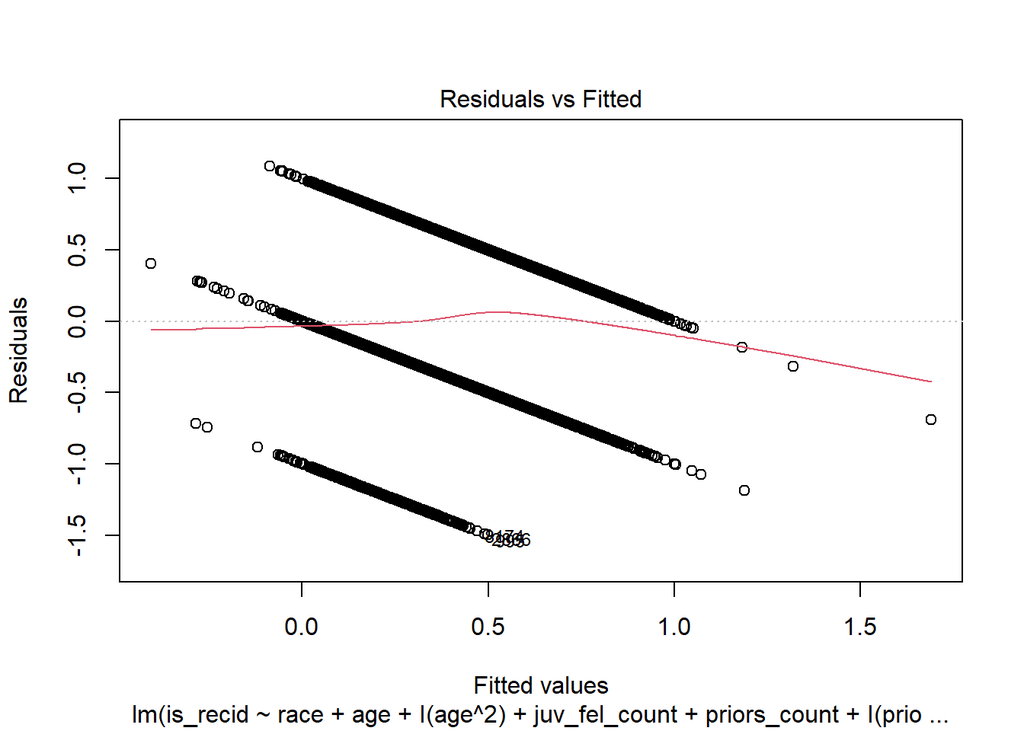

```r
plot(model_final, which = 1)
```

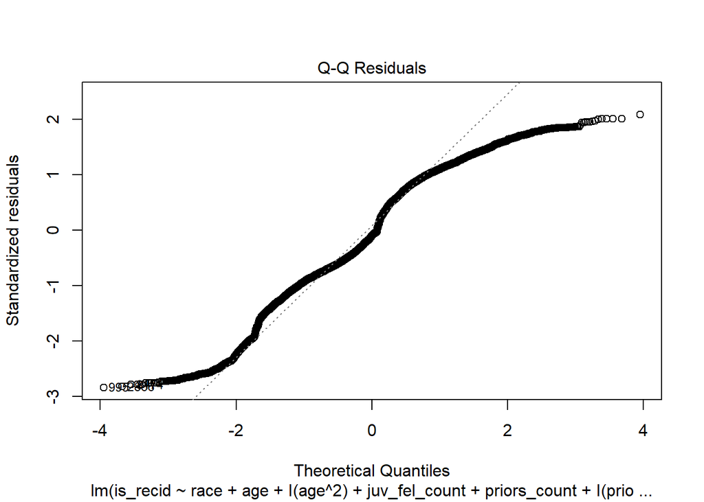

```r
plot(model_final, which = 2)
```

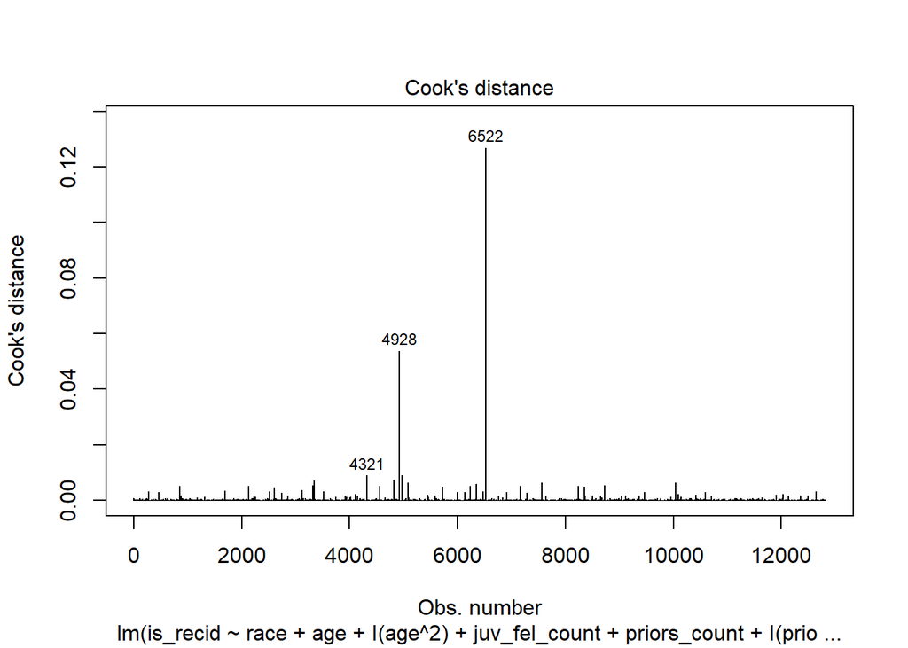

```r
plot(model_final, which = 4)
```

Regarding model adequacy, the final model does capture nonlinear effects and interactions with low performance. However, we observe that the response variable is binary, normality not fully reached, and our variance is not constant.

Some possible remedies would be to collect more data, consider using alternate nonlinear models, and use logistic regression.

Step 3:

```r
pred_test <- predict(model_final, newdata = testData)
RMSE <- sqrt(mean((testData$is_recid - pred_test)^2))
RMSE
```

```
## [1] 0.5314059
```

```r
summary(model_final)$adj.r.squared
```

```
## [1] 0.1585863
```

```r
SSE_test <- sum((testData$is_recid - pred_test)^2)
SST_test <- sum((testData$is_recid - mean(trainData$is_recid))^2)
R2_test <- 1 - SSE_test / SST_test
R2_test
```

```
## [1] 0.1607688
```

RMSE = 0.5314059, training R^2 = 0.1585863, and testing R^2 = 0.1607688. This indicates low predictive performance with minimal overfitting because we have nearly identical training and testing R^2 values.

Step 4:

One of the main takeaways from the model is that we are able to see non linearity in many of our variables, such as prior_counts. This model would work much better if our response variable was not binary.

I believe that adding interactions and dropping predictors were the most influential. We add interactions to explain more variance in the model and drop predictors that do not contribute significantly. I also balanced fit and interpretability by using partial F-tests to provide meaningful improvements in model fit.